# ggraph and visualization

Steps:

- map variables to aesthetics with `aes()`
- change appearances with `scale_`

This layer can be skipped but generally you use `aes()` to map attributes for further use in the `scale_*` functions.

[figure not shown]

```r
ggraph(g_got,layout = "stress")+
  geom_edge_link0(aes(edge_width = Weight),edge_colour = "grey66")+
  geom_node_point(aes(fill = clu,size = size),shape = 21)+
  geom_node_text(aes(filter = size >= 26, label = name),family="serif")+
  theme_graph()+
  theme(legend.position = "none")
```

To work out the variable type you can use the table below:

| Aesthetic | Variable type | Description |
| --- | --- | --- |
| node | size | continuous |
| edge | width | continuous |
| node colour/fill | categorical/continuous | use a gradient for continuous variables |
| edge colour | continuous | categorical only if there are different types of edges |
| node shape | categorical | only if there are a few categories (1-5). Colour should be the preferred choice |
| edge | linetype | categorical only if there are a few categories (1-5). Colour should be the preferred choice |
| node/edge alpha | continuous |  |

For `ggraph` colours are assigned in the order of the unique values of the categorical variable. They are usually set as `factors` or if it is a character, then sorting the unique values.

To have more control over colours you can use a vector with colours

```r
got_palette2 <- c("5" = "#1A5878","3" = "#C44237","2" = "#AD8941",
                  "1" = "#E99093", "4" = "#50594B")
```

`scale_fill_manual(values = got_palette)`

To select colours you can use this [link](https://www.htmlcsscolor.com/)

Compare

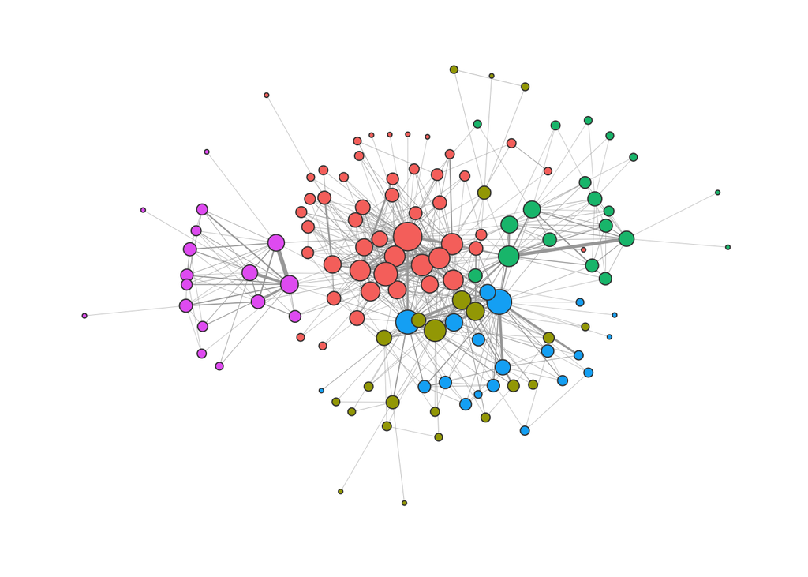

```r
ggraph(g_got,layout = "stress")+
geom_edge_link0(aes(edge_width=Weight),
                edge_colour="grey66")+
geom_node_point(aes(fill=clu,size=size),
                shape=21,col="grey25")+
scale_edge_width_continuous(range=c(0.1,1.5))+
scale_size_continuous(range=c(1,8))+
theme_graph()+
theme(legend.position = "none")
```

and

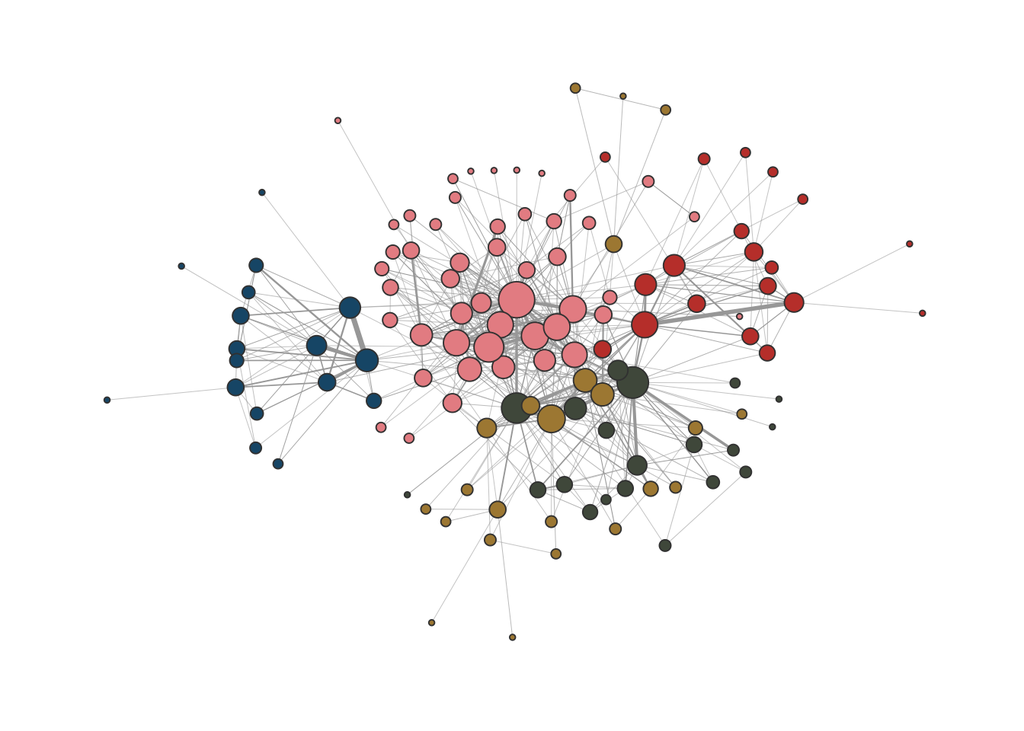

```r
got_palette2 <- c("5" = "#1A5878","3" = "#C44237","2" = "#AD8941",
                  "1" = "#E99093", "4" = "#50594B")

ggraph(g_got,layout = "stress")+
geom_edge_link0(aes(edge_width=Weight),
                edge_colour="grey66")+
geom_node_point(aes(fill=clu,size=size),
                shape=21,col="grey25")+
scale_edge_width_continuous(range=c(0.1,1.5))+
scale_size_continuous(range=c(1,8))+
scale_fill_manual(values=got_palette2)+
theme_graph()+
theme(legend.position = "none")
```

For easy colour selection you can also use `scale_fill_brewer()` and `scale_colour_brewer()` from `ggplot2`. You can see the palettes they offer at [colorbrewer2.org](https://colorbrewer2.org/#type=sequential&scheme=BuGn&n=3) .

.

[figure not shown]

```r
ggraph(g_got,layout = "stress")+
  geom_edge_link0(aes(edge_width = Weight),edge_colour = "grey66")+
  geom_node_point(aes(fill = clu,size = size),shape = 21)+
  geom_node_text(aes(filter = size >= 26, label = name),family = "serif")+
  scale_fill_brewer(palette = "Blues")+
  scale_edge_width_continuous(range = c(0.2,3))+
  scale_size_continuous(range = c(1,6))+
  theme_graph()+
  theme(legend.position = "none")
```

Some popular palettes include

| Type | Palettes |
| --- | --- |
| Diverging | BrBG, PiYG, PRGn, PuOr, RdBu, RdGy, RdYlBu, RdYlGn, Spectral |
| Qualitative | Accent, Dark2, Paired, Pastel1, Pastel2, Set1, Set2, Set3 |
| Sequential | Blues, BuGn, BuPu, GnBu, Greens, Greys, Oranges, OrRd, PuBu, PuBuGn, PuRd, Purples, RdPu, Reds, YlGn, YlGnBu, YlOrBr, YlOrRd |

**themes**: control the overall look of the plot (e.g. axis, background, grids, etc.)

```r
theme_graph()+
theme(legend.position = "none")
```

`theme_graph()`: remove the default `ggplot` theme

`theme(legend.position = "none")`: controls the legend. Possible options are “none”, “left”, “right”, “bottom”, “top”, or two-element numeric vector.

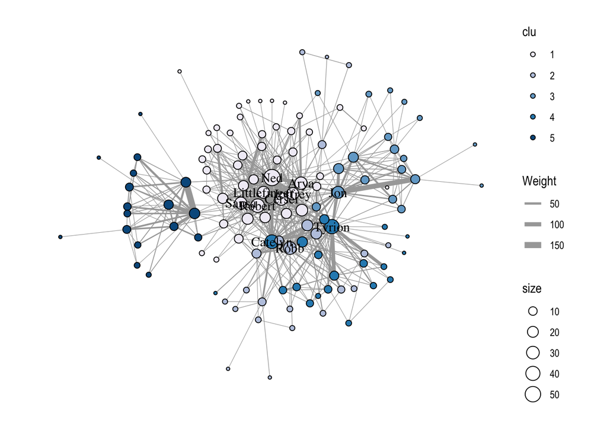

```r
ggraph(g_got,layout = "stress")+
  geom_edge_link0(aes(edge_width = Weight),edge_colour = "grey66")+
  geom_node_point(aes(fill = clu,size = size),shape = 21)+
  geom_node_text(aes(filter = size >= 26, label = name),family = "serif")+
  scale_fill_brewer(palette = "PuBu")+
  scale_edge_width_continuous(range = c(0.2,3))+
  scale_size_continuous(range = c(1,6))+
  theme_graph()+
  theme(legend.position = "right")
```